# Estadistica Descriptiva en R

# Datos de trabajo

Cargamos los datos con los que trabajaremos principalmente:

```r
library(readr)
library(tidyverse)

Datos <- read_csv("datosECV_Aragon.csv")
Datos <- Datos %>% select(3:10)
Datos <- Datos %>% rename("genero"="datosECVmas16.gen",
         "provincia"="nomprov", "ingresos"="ingnorm")
```

```r
head(Datos)
```

| provincia | genero | edad | nac | neduc | sitlab | ingresos | horas |
| --- | --- | --- | --- | --- | --- | --- | --- |
| Huesca | 1 | 3 | 1 | 3 | 1 | 21237.1 | 36.42 |
| Huesca | 2 | 2 | 1 | 2 | 1 | 17810.8 | 31.72 |
| Huesca | 1 | 1 | 1 | 2 | 1 | 11889.1 | 31.88 |
| Huesca | 1 | 1 | 1 | 2 | 1 | 16000.5 | 38.18 |
| Huesca | 1 | 1 | 1 | 2 | 3 | 21169.6 | 0.00 |
| Huesca | 1 | 2 | 1 | 2 | 1 | 16001.3 | 34.52 |

Las definiciones de las variables son las siguientes:

- **provincia**: indica la provincia de la comunidad de Aragón a la que pertenecen los individuos de la muestra.
- **genero**: indica el sexo de los individuos de la muestra. Si es masculino toma valor 1, si es femenino toma 2.
- **edad**: indica el rango de edad de los individuos de la muestra. Toma el valor 1 si la edad esta entre 16 y 24 años, el 2 si la edad esta entre 25 y 49 años, el 3 si la edad esta entre 50 y 64 años, y el 4 si la edad es mayor o igual a 65 años
- **nacionalidad** (**nac**): indica la nacionalidad de los individuos de la muestar. Si es española toma el valor 1, si es otra nacionalidad toma el 2.
- **situacion laboral** (**sitlab**): indica la situacion laboral de los individuos de la muestra. Toma el valor 1 si la persona trabaja, el 2 si esta desempleado, y el 3 si esta inactivo.
- **ingresos** : indica los ingresos de los individuos de la muestra.
- **horas** : indica el numero de horas que trabajan los individuos de la muestra.

# Variables Estadisticas

$$\begin{gather*}
X_k= \begin{pmatrix}
x_{1k} \\
x_{2k}\\
... \\
x_{nk}
\end{pmatrix}
\end{gather*}$$

es una **variable estadística** porque es un vector con los valores/observaciones de la variable $X_k$ para $n$ indiviuos/elementos de una muestra.

Donde: $x_{ik}$ es el valor u observación de la variable $X_k$ para el elemento $i$ de la muestra ($i$-esima observación de la variable $X_k$).

# Matriz de Datos

En general, si hemos observado $p$ variables sobre una muestra $\varepsilon$ de $n$ elementos o individuos ,

La matriz de datos $X$ de las variables $X_1,...,X_p$ medidas sobre los $n$ individuos o elementos de $\varepsilon$ es:
$$\begin{gather*}
X= \begin{pmatrix}
x_{11} & x_{12}&...&x_{1p}\\
x_{21} & x_{22}&...&x_{2p}\\
...&...&...&...\\
x_{n1}& x_{n2}&...&x_{np}
\end{pmatrix}
\end{gather*}$$

Observación: $X$ es una matriz $nxp$

## Representacion de la matriz de datos por filas

$$\begin{gather*}
X= \begin{pmatrix}
x_{1}^{t} \\
x_{2} ^t \\
... \\
x_{n} ^t
\end{pmatrix}
\end{gather*}$$

Donde:

$x_i ^t = (x_{i1}, x_{i2}, ..., x_{ip} )$ es el vector con los valores de las $p$ variables $X_1,...,X_p$ para el individuo/elemento $i$ de la muestra, con $i=1,...,n$

## Representacion de la matriz de datos por columnas

Podemos expresar:

$$\begin{gather*}
X= (X_1 , X_2 ,..., X_p )
\end{gather*}$$

Donde:
$$\begin{gather*}
X_k= \begin{pmatrix}
x_{1k} \\
x_{2k}\\
... \\
x_{nk}
\end{pmatrix}
\end{gather*}$$

para $k=1,2,...,p$

# Recorrido de una variable

El **recorrido** de una variable estadistica $X_k$ es el conjunto de valores que puede tomar la variable.

En funcion del recorrido de una variable podemos determinar si es **cuantitativa** o **categorica**. Clasificación que tiene una relevancia central en la estadística.

Ejemplos:

$X_k =$ Ingresos de 1000 empleados de Amazon $\Rightarrow$ $Recorrido(X_k) =[0, \infty )$

$X_k =$ Marca del coche de 50 futbolistas $\Rightarrow$ $Recorrido(X_k) = \lbrace Mercedes, Audi, ... \rbrace$

$X_k =$ Numero de chalets de 10 urbanizaciones $\Rightarrow$ $Recorrido(X_k) = \lbrace 0, 1, 2,... \rbrace$

# Tipos de variables estadisticas:

## Variables Cuantitativas y Categoricas:

Tipos de variables estadísticas:

La variable $X_k$ es **cuantitativa** si los elementos de su recorrido son conceptualmente numeros

La variable $X_k$ es **categorica** si los elementos de su recorrido son etiquetas o categorías (pueden ser numeros a nivel símbolico pero no a nivel conceptual)

En este trabajo se asumira que el recorrido de las variables categoricas son numeros, puesto que esto permitirá poder aplicarle algunos conceptos que no podrian aplicarse si su recorrido no fueran numeros, aunque, como se ha comentado, actuarán como etiquetas o categorías.

# Tipos de Variables Cuantitativas

## Variables Discretas y Continuas

Sea $X_k$ una variable {cuantitativa},

La variable $X_k$ es **discreta** si su recorrido es un conjunto numerable

La variable $X_k$ es **continua** si su recorrido no es numerable

**Observación:**

En particular, variables cuyo **recorrido** sea un conjunto **finito** serán **discretas**.

# Tipos de Variables Categoricas

Sea $X_k$ una variable **categorica** ,

$X_k$ es **r-aria** si su recorrido tiene **r** elementos que son categorias o etiquetas

En estadistica tienen particular importancia las variables categoricas **binarias** (2-aria).

## Variables Nominales y Ordinales

Sea $X_k$ una variable categorica $r$-aria,

La variable $X_k$ es **nominal** si **no existe una ordenacion** entre las $r$ categorias de su recorrido

La variable $X_k$ es **ordinal** si **existe una ordenacion** entre las $r$ categorias de su recorrido.

**Ejemplos:**

$Recorrido(X_k)= \lbrace Apple , Samsung, Oppo \rbrace \Rightarrow X_k$ es categorica nominal

$Recorrido(X_k)= \lbrace mal , regular, bien \rbrace \Rightarrow X_k$ es categorica ordinal

# Estadisticos descriptivos

Un estadistico descriptivo es una funcion de los elementos de una muestra.

En general, toda funcion aplicada sobre una variable estadistica $X_k$ es un estadistico.

A continuacion veremos algunos de los estadisticos descriptivos mas utilizados.

## Media Aritmetica

La media aritmetica de la variable $X_k$ se define como:
$$\begin{gather*}
\overline{X_k}= \frac{1}{n} \cdot \sum_{i=1}^{n} x_{ik}
\end{gather*}$$

Observación: en general a la media aritmetica se le llama simplemente media.

**Propiedades:**

$$\begin{gather*}
\sum_{i=1}^{n} \left( x_{ik} - \overline{X_k} \right) = 0
\end{gather*}$$

### Media Aritmetica en R

```r
mean(Datos$ingresos)
```

```
## [1] 14078.77
```

### Vector de medias

Dada una matriz de datos $X$ de tamaño $nxp$,

El vector de medias de X es:
$$\begin{gather*}
\overline{X}=( \overline{X_1} , \overline{X_2} , ... , \overline{X_p} )
^t
\end{gather*}$$

### Expresión matricial del vector de medias

La expresión matricial del vector de medias de X es:
$$\begin{gather*}
\overline{X}= \dfrac{1}{n} \cdot X\hspace{0.05cm}^t \cdot
\overrightarrow{1}_{nx1}
\end{gather*}$$

## Media Ponderada

Dada la variable $X_k=(x_{1k}, x_{2k},...,x_{nk})^t$

Dados unos pesos para cada una de las n observaciones de la variable $X_k$ : $w=(w_1,w_2,...,w_n)^t$

La **media ponderada** de la variable $X_k$ con el vector de pesos $w$ es:
$$\begin{gather*}
\overline{X_k} (w) = \dfrac{\sum_{i=1}^{n} x_{ik}\cdot w_i }{
\sum_{i=1}^{n} w_{i} }
\end{gather*}$$

## Media Geometrica

Dada la variable $X_k=(x_{1k}, x_{2k},...,x_{nk})^t$

La **media geometrica** de la variable $X_k$ es:
$$\begin{gather*}
\overline{X_k}_{geom} = \sqrt{\Pi_{i=1}^{n} x_{ik}} =
\sqrt{x_{1k}\cdot x_{2k}\cdot...\cdot x_{nk}}
\end{gather*}$$

## Mediana

La **mediana** de la variable $X_k$ es un valor tal que la {mitad} de las observaciones de $X_k$ son **inferiores** a él.

Dada la variable $X_k=(x_{1k}, x_{2k},...,x_{nk})^t$

Ordenamos sus valores de menor a mayor $x_{(1)k} < x_{(2)k} < ...< x_{(n)k}$

La mediana de la variable $X_k$ es:

$$\begin{equation*}
Mediana(X_k)= \left\lbrace\begin{array}{l} \dfrac{ x_{(n/2)k} + x_{(n/2
+ 1)k} }{2} \hspace{0.3cm},\text{ si n es {par}} \\ x_{(\lceil n/2
\rceil)k} \hspace{0.3cm},\text{ si n
es {impar} } \end{array}\right.
\end{equation*}$$

### Mediana en R

Podemos calcular la mediana en R usando la función

```r
median(Datos$ingresos)
```

```
## [1] 12331
```

Podemos comprobar que efectivamente la mitad de las observaciones de la variable ingresos son menores que la mediana.

```r
sum(Datos$ingresos < median(Datos$ingresos) )/length(Datos$ingresos)
```

```
## [1] 0.5
```

## Cuantiles

El cuantil de orden $p$ de la variable $X_k$ es el valor $Q(p, X_k)$ tal que la proporcion de observaciones de $X_k$ que son menores que $Q(p, X_k)$ es $p$

Más formalmente:

$Q(p, X_k)$ es el cuantil $p$ de $X_k$ $\Leftrightarrow$ $\dfrac{\# \lbrace i=1,..,n \hspace{0.15cm} / \hspace{0.15cm} x_{ik} < Q(p, X_k) \rbrace}{n} = p$

Observación: la mediana el es cuantil de orden $p=0.5$

### Cuantiles en R

```r
quantile(Datos$ingresos)
```

```
##       0%      25%      50%      75%     100%
##  -999.50  8310.60 12331.00 18269.38 58470.40
```

```r
quantile(Datos$ingresos, 0.85)
```

```
##     85%
## 21840.8
```

```r
quantile(Datos$ingresos, 0.37)
```

```
##      37%
## 10329.74
```

## Varianza y Desvación Típica

La varianza de la variable $X_k$ es:
$$\begin{equation*}
\sigma^2(X_k)= \dfrac{1}{n} \sum_{i=1}^{n} (x_{ik} - \overline{x_k})^2
\end{equation*}$$

La desviación típica de la variable $X_k$ es:
$$\begin{equation*}
\sigma(X_k)= \sqrt{\dfrac{1}{n} \sum_{i=1}^{n} (x_{ik} -
\overline{x_k})^2}
\end{equation*}$$

### Varianza y Desvación Típica en R

```r
var(Datos$ingresos)
```

```
## [1] 67924827
```

```r
sd(Datos$ingresos)
```

```
## [1] 8241.652
```

# Matriz de datos centrada

Dada una matriz de datos $X $ de tamaño $nxp$

$X$ es **centrada** $\Leftrightarrow$ la **media** de sus variables ( **columnas**) es **cero**

**Operación de centrado:**

La operacion para centrar $X$ es la siguiente:
$$\begin{gather*}
X - \overrightarrow{1}_{nx1} \cdot \overline{x}\hspace{0.05cm}^t
=H_{n}\cdot X_{nxp}
\end{gather*}$$

es una **matriz centrada** (la media de sus columnas es cero).

Donde:

$$\begin{gather*}
H_{n}=I_n - \dfrac{1}{n} \cdot \overrightarrow{1}_{nx1} \cdot
\overrightarrow{1^t}
\end{gather*}$$

es la **matriz de centrado**.

# Variables Escaladas

Dada la variable cuantitativa $X_k$

$X_k^{scale}$ es la variable $X_k$ **escalada**, si se cumple que:

$$\begin{equation*}
x_{ik}^{scale}= \dfrac{ x_{ik} - \overline{X_k} }{ \sigma(X_k)}
\end{equation*}$$

para $i=1,...,n$

## Matriz de datos escalada

Sea $X=(X_1,...,X_p)$ una matriz de datos de $p$ variables,

$X^{scale}=(X_1^{scale},...,X_p^{scale})$ es la matriz de datos $X$ **escalada**.

# Covarianza

Dadas las variables $X_k=(x_{1k}, x_{2k},...,x_{nk})^t$ y $X_r=(x_{1r}, x_{2r},...,x_{nr})^t$

La covarianza entre las variables $X_j$ y $X_r$ se define como:

$$\begin{gather*}
S(X_k, X_r) = \frac{1}{n} \cdot \sum_{i=1}^{n} (x_{ik} -
\overline{x_k})\cdot (x_{ir} - \overline{x_r})
\end{gather*}$$

## Propiedades de la covarianza

- $S(X_k,X_r) \in (-\infty, \infty)$
- $S(X_k,X_r) \hspace{0.1cm} = \hspace{0.1cm} \dfrac{1}{n} \sum_{i=1}^{n} (x_{ik} \cdot x_{ir}) - \overline{x_k} \cdot \overline{x_r} \hspace{0.2cm} = \hspace{0.2cm} \overline{x_k\cdot x_r} - \overline{x_k} \cdot \overline{x_r}$
- $S(X_k, a + b\cdot X_r) = b\cdot S(X_k,X_r)$
- $S(X_k,X_r) = S(X_r,X_k)$
- $S(X_k,X_r) > 0 \Rightarrow$ **Relación creciente** entre $X_k$ y $X_r$
- $S(X_k,X_r) < 0 \Rightarrow$ **Relación decreciente** entre $X_k$ y $X_r$
- $S(X_k,X_r) = 0 \Rightarrow$ **No hay relación** entre $X_k$ y $X_r$

### Covarianza en R

```r
cov(Datos$ingresos , Datos$horas)
```

```
## [1] 32453.53
```

## Matriz de Covarianzas

La **matriz de covarianzas** de una matriz de datos $X$ es:

$$\begin{gather*}
S_X = \left( \hspace{0.2cm} S(X_k , X_r) \hspace{0.2cm}
\right)_{k,r=1,...,p}
\end{gather*}$$

**Expresión matricial de la matriz de covarianzas:**

$$\begin{gather*}
S_X=\dfrac{1}{n} \cdot X\hspace{0.1cm}^t \cdot H \cdot X
\end{gather*}$$

Donde: $H$ es la matriz de centrado

### Matriz de Covarianzas en R

```r
X1<-rnorm(30)
X2<-rnorm(30)
X3<-rnorm(30)
X4<-rnorm(30)
```

```r
cov(cbind(X1,X2,X3,X4))
```

```
##             X1          X2          X3         X4
## X1  1.21658347 -0.06154167  0.14548120 -0.3579662
## X2 -0.06154167  1.10326428 -0.08654819  0.2827292
## X3  0.14548120 -0.08654819  0.43705601 -0.2504242
## X4 -0.35796619  0.28272919 -0.25042418  1.2638200
```

# Correlacion Lineal de Pearson

Dadas las variables $X_k=(x_{1k}, x_{2k},...,x_{nk})^t$ y $X_r=(x_{12r}, x_{2r},...,x_{nr})^t$

La **correlacion lineal de Pearson** entre las variables $X_k$ y $X_r$ se define como:

$$\begin{equation*}
r(X_k,X_r) = \frac{S(X_k,X_r)}{S(X_k) \cdot S(X_r)}
\end{equation*}$$

## Propiedades de la correlación lineal de Pearson

- $r(X_k,X_r) \in [-1,1]$
- $r_{X_k,a + b\cdot X_r} = r(X_k,X_r)$
- El signo de $r(X_k,X_r)$ coincide con el de $S(X_k,X_r) $
- $r(X_k,X_r) = \pm 1 \Rightarrow$ Relacion Lineal Perfecta entre $X_k$ e $X_r$
- $r(X_k,X_r) = 0 \Rightarrow$ No Existe Relacion Lineal entre $X_k$ e $X_r$
- $r(X_k,X_r) = 0 \Rightarrow$ No Existe Relacion Lineal entre $X_k$ e $X_r$
- $r(X_k,X_r) \rightarrow \pm 1 \Rightarrow$ Relacion Lineal Fuerte entre $X_k$ e $X_r$
- $r(X_k,X_r) \rightarrow 0 \Rightarrow$ Relacion Lineal Debil entre $X_k$ e $X_r$
- $r(X_k,X_r) >0 \Rightarrow$ Relacion Creciente entre $X_k$ e $X_r$
- $r(X_k,X_r) <0 \Rightarrow$ Relacion Decreciente entre $X_k$ e $X_r$

### Correlaciones de Pearson en R

```r
cor(Datos$ingresos, Datos$horas  , method = "pearson")
```

```
## [1] 0.2308945
```

## Matriz de correlaciones

La **matriz de correlaciones** de Pearson de la matriz de datos X es:

$$\begin{gather*}
R_X = \left( \hspace{0.2cm} r(X_k , X_r) \hspace{0.2cm}
\right)_{k,r=1,...,p}
\end{gather*}$$

**Expresión matricial de la matriz de correlaciones**

$$\begin{gather*}
R_X= D_s^{-1} \cdot S_X \cdot D_s^{-1}
\end{gather*}$$

Donde:
$$\begin{gather*}
D_s = diag \left( \sigma(X_1) , \sigma(X_2) ,..., \sigma(X_p) \right)
\end{gather*}$$

### Matriz de correlaciones en R

```r
cor(cbind(X1,X2,X3,X4))
```

```
##             X1          X2         X3         X4
## X1  1.00000000 -0.05312006  0.1995112 -0.2886878
## X2 -0.05312006  1.00000000 -0.1246378  0.2394353
## X3  0.19951124 -0.12463777  1.0000000 -0.3369497
## X4 -0.28868781  0.23943535 -0.3369497  1.0000000
```

# Distribución de Frecuencias

## Frecuencia Absoluta de un elemento

Dada una variable $X_k=(x_{1k}, x_{2k},...,x_{nk})^t$ y $a \in Recorrido(X_k)$

La **frecuencia absoluta** del **elemento** $a$ en $X_k$ se define como:

$$\begin{gather*}
Fabs(a ,X_k) \hspace{0.1cm}=\hspace{0.1cm} \# \lbrace i / x_{ik}=a
\rbrace \hspace{0.1cm} = \\ \hspace{0.1cm} =\hspace{0.1cm} \text{nº de
observaciones de la variable $X_k$ que coinciden con el valor $a$ }
\end{gather*}$$

Por ejemplo: $F(a=1000, X_k)$ podria ser el numero de empleados de cierta empresa con un salario de $a=1000$ euros.

**Observación:**

Si $X_k$ es continua lo normal es que $Fabs(a,X_k) = 0$ para muchos valores $a$

### Frecuencia Absoluta de un elemento en R

Frecuencia absoluta para un elemento $\Rightarrow$ util para variables categoricas

```r
frecuencia_absoluta_elemento <-
function( variable, elemento){

frecuencia_absoluta_elemento <-
sum(variable == elemento)

return(frecuencia_absoluta_elemento)
}
```

```r
frecuencia_absoluta_elemento( round(Datos$ingresos, 3),
                              8736.2)
```

```
## [1] 1
```

```r
frecuencia_absoluta_elemento( round(Datos$ingresos, 3),
                              8736)
```

```
## [1] 0
```

```r
frecuencia_absoluta_elemento(Datos$genero , 1)
```

```
## [1] 615
```

```r
frecuencia_absoluta_elemento(Datos$neduc , 3)
```

```
## [1] 202
```

## Frecuencia Absoluta de un conjunto

Dada una variable $X_k=(x_{1k}, x_{2k},...,x_{nk})^t$ y $A \subset Recorrido(X_k)$

La **frecuencia absoluta** del **conjunto** $A$ en $X_k$ se define como:

$$\begin{gather*}
Fabs(A, X_k) = \sum_{a \in A} Fabs(a , X_k ) = \\
= \text{ nº de observaciones de $X_k$ que pertenecen a $A$}
\end{gather*}$$

Por ejemplo: $Fabs(A=[500,1500] , X_k)$ podria ser el numero de empleados con un salario entre 500 y 1500 euros.

**Observación:**

$Fabs([b_1,b_2], X_k)$ es un caso particular de $Fabs(A, X_k)$ con $A=[b_1,b_2]$

### Frecuencia Absoluta de un intervalo en R

Frecuencia absoluta para un intervalo (conjunto continuo) $\Rightarrow$ util para variables cuantitativas (sobre todo continuas)

```r
frecuencia_absoluta_intervalo <-

function( variable, cota_inferior, cota_superior ){

frecuencia_absoluta_intervalo <-

sum(variable >= cota_inferior &
variable <= cota_superior)

return(frecuencia_absoluta_intervalo)
}
```

```r
frecuencia_absoluta_intervalo(Datos$ingresos , 8000, 12000)
```

```
## [1] 305
```

```r
frecuencia_absoluta_intervalo(Datos$neduc , 3, 4)
```

```
## [1] 202
```

### Frecuencia Absoluta de un conjunto discreto en R

Frecuencia absoluta para un conjunto discreto $\Rightarrow$ util para variables categoricas y cuantitativas discretas

```r
frecuencia_absoluta_conjunto_discreto <-

function(variable, conjunto){
cont=0
for( i in conjunto){

  if( any(variable == i) ) {

  cont = cont + sum(variable==i)
  }
}
return(cont)
}
```

```r
A=c(3, 4)

frecuencia_absoluta_conjunto_discreto(Datos$neduc , A)
```

```
## [1] 202
```

```r
A=c(1,3,4)

frecuencia_absoluta_conjunto_discreto(Datos$neduc , A)
```

```
## [1] 645
```

## Frecuencia Relativa de un elemento

Dada una variable $X_k=(x_{1k}, x_{2k},...,x_{nk})^t$ y $a \in Recorrido(X_k)$

La **frecuencia relativa** del **elemento** $a$ en $X_k$ se define como:

$$\begin{gather*}
Fre(a,X_k) = \dfrac{Fabs(a,X_k) }{n} = \\ =\text{ proporcion de
observaciones de $X_k$ que coinciden con el valor $a$}
\end{gather*}$$

Por ejemplo: $Fre(a=1000,X_k)$ podria ser la proporcion de empleados de cierta empresas con un salario de 1000 euros.

## Frecuencia Relativa de un conjunto

Dada una variable $X_k=(x_{1k}, x_{2k},...,x_{nk})^t$ y $A \subset Recorrido(X_k)$

La **frecuencia relativa** del **conjunto** $A$ en $X_k$ se define como:
$$\begin{gather*}
Fre(A,X_k) = \dfrac{Fabs(A ,X_k) }{n} = \\ = \text{ proporción de
observaciones de $X_k$ que pertenecen a $A$}
\end{gather*}$$

Por ejemplo: $Fre(A=[500,1500],X_k)$ podria ser la proporcion de empleados de cierta empresas con un salario entre 500 y 1500 euros.

### Frecuencia Relativa de un elemento en R

```r
frecuencia_relativa_elemento <-

function( variable , elemento ){

frecuencia_relativa_elemento <-

frecuencia_absoluta_elemento(variable , elemento)/
  length(variable)

  return(frecuencia_relativa_elemento)

}
```

```r
frecuencia_relativa_elemento(Datos$genero, 1)
```

```
## [1] 0.4975728
```

### Frecuencia Relativa de un intervalo en R

```r
frecuencia_relativa_intervalo <-

  function( variable, cota_inferior, cota_superior ){

  frecuencia_relativa_intervalo <-
  frecuencia_absoluta_intervalo(variable ,
    cota_inferior, cota_superior)/
    length(variable)

  return(frecuencia_relativa_intervalo)

}
```

```r
frecuencia_relativa_intervalo(Datos$ingresos, 8000, 12000)
```

```
## [1] 0.2467638
```

### Frecuencia Relativa de conjunto discreto en R

```r
frecuencia_relativa_conjunto_discreto <-
function( variable, conjunto ){

frecuencia_relativa_conjunto_discreto <-
frecuencia_absoluta_conjunto_discreto(variable,conjunto)/
  length(variable)

  return(frecuencia_relativa_conjunto_discreto)

}
```

```r
A=c(1, 3)

frecuencia_relativa_conjunto_discreto(Datos$neduc, A)
```

```
## [1] 0.5218447
```

## Frecuencias Acumuladas

La **frecuencia absoluta acumulada** del elemento $a$ en $X_k$ se define como:

$$\begin{gather*}
Fabscum(a ,X_k)=Fabs \left( \lbrace i=1,...,n / x_{ik} \leq
a \rbrace , X_k \right) = \\ = \text{nº de observaciones de $X_k$ que
son menores o iguales que $a$}
\end{gather*}$$

La **frecuencia relativa acumulada** del elemento $a$ en $X_k$ se define como:
$$\begin{gather*}
Frecum(a,X_k)= \dfrac{Fabscum(a,X_k)}{n} \\ = \text{proporcion de
observaciones de $X_k$ que son menores o iguales que $a$}
\end{gather*}$$

### Frecuencias Absoluta Acumulada en R

```r
frecuencia_absoluta_acumulada <-

function(variable, elemento){

frecuencia_absoluta_acumulada <-
frecuencia_absoluta_intervalo(variable,-Inf,elemento)

 return(frecuencia_absoluta_acumulada)
}
```

```r
frecuencia_absoluta_acumulada(Datos$ingresos, 8000)
```

```
## [1] 289
```

### Frecuencia Relativa Acumulada en R

```r
frecuencia_relativa_acumulada <-

function(variable, elemento){

frecuencia_relativa_acumulada <-

frecuencia_absoluta_acumulada(variable,elemento)/
  length(variable)

  return(frecuencia_relativa_acumulada)
}
```

```r
frecuencia_relativa_acumulada(Datos$ingresos, 8000)
```

```
## [1] 0.2338188
```

# Tabla de Frecuencias

Vamos a crear una función en R a la que le metemos una variable y nos debuelve una tabla con las frecuencias de esa variable.

Las caracteristicas de la función son las siguientes:

- **Entrada:** matriz de datos $X$
- **Entrada:** variable $V1$ de $X$
- $V1$ debe estar cargadas en R como vector
- $V1$ puede ser una variable categorica o cuantitativa categorizada
- El recorrido de $V1$ tiene que ser $0:p1$ , con $p1=1,2,3,...$
- **Entrada:** $p1$

```r
Tabla_Frecuencias  <- function(X, V1 ,p1 ){

tabla<- matrix(NA, nrow=p1+1, ncol= 4 )
X<- cbind(X, V1)

for(i in 0:p1){

  tabla[i+1, 1 ] <-  dim( ( X  %>% filter(V1==i ) ) )[1]
}

for(i in 0:p1){

  tabla[i+1, 2 ] <- ( dim( ( X  %>% filter(V1==i ) ) )[1] / dim(X)[1] )
}

for(i in 0:p1){

  tabla[i+1, 3] <- cumsum(tabla[1:(i+1) ,1])[i+1]
}

for(i in 0:p1){

  tabla[i+1, 4] <- cumsum(tabla[1:(i+1) ,2])[i+1]
}

 rownames(tabla)<-0:p1
 colnames(tabla)<-c("F.Abs","F.Rel", "F.Abs.Cum","F.Rel.Cum")

 tabla <- as.data.frame(tabla)

 return(tabla)
}
```

## Tabla de Frecuencias para variables categoricas

Para usar esta funcion primero debomos redefinir correctamente la variable usada:

- La variable escogida debe estar cargada en R
- Usando una **variable categorica** $\Rightarrow$ sus categorias deben ser $0,1,...,p1$

```r
# neduc es una variable categorica 3-aria --> debe recodificarse para que sus categorias sean 0,1,2

Datos$neduc<-recode(Datos$neduc, "1"="0", "2"="1", "3"="2")

neduc<- Datos$neduc

Tabla_Frecuencias(X=Datos, V1=neduc, p1=2)
```

|  | F.Abs | F.Rel | F.Abs.Cum | F.Rel.Cum |
| --- | --- | --- | --- | --- |
| 0 | 443 | 0.3584142 | 443 | 0.3584142 |
| 1 | 591 | 0.4781553 | 1034 | 0.8365696 |
| 2 | 202 | 0.1634304 | 1236 | 1.0000000 |

## Tabla de Frecuencias para variables cuantitativas

Para usar la función Tabla_Frecuencias() primero debemos redefinir correctamente la variable usada:

- La variable escogida debe estar cargada en R
- Usando una **variable cuantitativa** $\Rightarrow$ **hay que categorizarla** usando alguna regla de categorización, como la regla de la media, mediana, cuartiles, Scott…

### Categorización de Variables Cuantitativas

Dada una variable cuantitativa $X_k=(x_{1k},...,x_{nk})^t$ , se trata de obtener su version categorizada $X_k^{cat}=(x_{1k}^{cat},...,x_{nk}^{cat})^t$

La version categorizada de una variable cuantitativa $X_k$ es otra variable $X_k^{cat}$ que es categorica, y que toma valores en funcion de las observaciones de $X_k$.

La idea es la siguiente:

Dada una variable cuantitativa $X_k$ ,

Hay que definir los **intervalos de categorización** de $X_k$, que son una serie de intervalos $[L_{1},L_{2}), [L_{2}, L_{3}),..., [L_{\lambda},L_{\lambda+1})$ , tales que:

- Son disjuntos dos a dos (no comparten elementos).
- Toda observación/valor de $X_k$ pertenece a algún intervalo.
- Tienen la misma amplitud (mismo tamaño).

Una vez definidos los intervalos de categorizacion de $X_k$ se aplica la siguiente regla para definir $X_k^{cat}$

$$\begin{equation*} x^{cat}_{ik} =
\left\lbrace\begin{array}{l} 0, \text{ si $x_{ik} \in
[L_{1},L_{2})$} \\ 1, \text{ si $x_{ik} \in [L_{2},L_{3}) $}
\\ ...
\\ \lambda, \text{ si $x_{ik} \in [L_{\lambda},L_{\lambda+1}) $}
\end{array}\right.
\end{equation*}$$

En definitiva:

$$\begin{equation*}
x_{ik} \in [L_{r}, L_{r+1}] \ \Leftrightarrow \ x_{ik}^{cat} = r-1
\end{equation*}$$

para $r=1,...,\lambda > 0$

Donde:

$[L_{r}, L_{r+1}]$ es el intervalo $r$-esimo de los intervalos de categorizacion de $X_k$

Exiten diferentes reglas para definir los intervalos de categorizacion de una variable cuantitativa. En este trabajo veremos las reglas de la mediana, media, cuartiles y Scott.

### Regla de la Mediana

Según la regla de la mediana los intervalos de categorización de $X_k$ son:

$$\begin{gather*}
[Min(X_k), Mediana(X_k)], (Mediana(X_k), Max(X_k)]
\end{gather*}$$

Por tanto, a partir de $X_k$ se obtiene la variable $X_k^{cat}$ definida como:

$$\begin{equation*} x^{cat}_{ik} =
\left\lbrace\begin{array}{l} 0, \text{ si $x_{ik} \in [Min(X_k),
Mediana(X_k)]$} \\ 1, \text{ si $x_{ik} \in (Mediana(X_k),
Max(X_k)]$} \end{array}\right.
\end{equation*}$$

### Regla de la Media

Según la regla de la media los intervalos de categorización de $X_k$ son:

$$\begin{gather*}
\left[ Min(X_k) \hspace{0.02cm} ,\hspace{0.02cm} \overline{x_k} \right],
\left(\overline{x_k} \hspace{0.02cm},\hspace{0.02cm} Max(X_k)\right]
\end{gather*}$$

Por tanto, a partir de $X_k$ se obtiene la variable $X_k^{cat}$ definida como:

$$\begin{equation*}
x^{cat}_{ik} = \left\lbrace\begin{array}{l} 0, \text{ si $x_{ik} \in
[Min(X_k)\hspace{0.02cm},\hspace{0.02cm} \overline{x_k} ]$} \\ 1, \text{
si $x_{ik} \in (\overline{x_k} \hspace{0.02cm},\hspace{0.02cm}
Max(X_k)] $} \end{array}\right.
\end{equation*}$$

### Regla de los Cuartiles

Según la regla de la cuartiles los intervalos de categorización de $X_k$ son:

$$\begin{gather*}
\left[ Min(X_k) \hspace{0.03cm} ,\hspace{0.03cm} Q(0.25,X_k) \right],
\left(Q(0.25,X_k) \hspace{0.02cm},\hspace{0.02cm} Q(0.50,X_k)\right] ,
\\ \left(Q(0.50,X_k) \hspace{0.02cm},\hspace{0.02cm} Q(0.75,X_k)\right],
\left(Q(0.75,X_k) \hspace{0.02cm},\hspace{0.02cm} Max(X_k)\right]
\end{gather*}$$

Por tanto, a partir de $X_k$ se obtiene la variable $X_k^{cat}$ definida como:

$$\begin{equation*} x^{cat}_{ik} =
\left\lbrace\begin{array}{l} 0, \text{ si $x_{ik} \in \left[ Min(X_k)
\hspace{0.03cm} ,\hspace{0.03cm} Q(0.25,X_k) \right] $} \\ 1, \text{ si
$x_{ik} \in \left[ Q(0.25 , X_k) , Q(0.50 , X_k)\right] $}
\\ 2, \text{ si $x_{ik} \in (Q(0.50 , X_k) , Q(0.75 , X_k)] $} \\ 3,
\text{ si $x_{ik} \in \left(Q(0.75,X_k) \hspace{0.02cm},\hspace{0.02cm}
Max(X_k)\right] $} \end{array}\right.
\end{equation*}$$

### Regla de Scott

Según la regla de la Scott los intervalos de categorización de $X_k$ son: $[L_{1},L_{2}), [L_{2}, L_{3}),...,[L_{ \lambda},L_{ \lambda+1})$

Por tanto, a partir de $X_k$ se obtiene la variable $X_k^{cat}$ definida como:

$$\begin{equation*} x^{cat}_{ik} =
\left\lbrace\begin{array}{l} 0, \text{ si $x_{ik} \in
[L_{1},L_{2})$} \\ 1, \text{ si $x_{ik} \in [L_{2},L_{3}) $}
\\ ...
\\ \lambda, \text{ si $x_{ik} \in [L_{\lambda},L_{\lambda+1}) $}
\end{array}\right.
\end{equation*}$$

El procedimiento para calcular los intervalos de Scott es el siguiente:

1. Determinar el número de clases intervalos:

Primero hay que determinar la $A_t$ de las clases, que se calcula como:

$$\begin{equation*}
A_{t} = 3.5 \cdot S (X_k) \cdot n^{-1/3}
\end{equation*}$$

El será:
$$\begin{equation*}
\lambda=\left\lceil \frac{Max(X_k)-Min(X_k)}{A_{t}} \right\rceil
\end{equation*}$$

2. Determinar el ancho de los intervalos:

La de los intervalos $A$ será la misma para todos ellos y viene definida por:

$$\begin{equation*}
A=\left\lceil \frac{Max(X_k)-Min(X_k)}{\lambda} \right\rceil
\end{equation*}$$

3. Determinar los extremos de los intervalos:

Los intervalos serán: $[L_{1},L_{2}), [L_{2}, L_{3}),...,[L_{ \lambda},L_{ \lambda+1})$

Donde $L_{i}, L_{i+1}$ son los intervalos inferior y superior, respectivamente, del intevalo $i$-esimo.

La regla de Scott para determinar los **extremos de los intervalos** es la siguiente:

$$\begin{gather*}
L_{1}= Min(X_k) - c \\
L_{2}=L_{1} + A \\
L_{3}=L_{2} + A\\
... \\
L_{\lambda+1}=L_{\lambda} + A
\end{gather*}$$

Donde: $c \geq 0$ debe ser elegido a conveniencia del analista.

En general:

$$\begin{gather*}
L_{i}=L_{1} + (i-1)\cdot A \hspace{0.5cm} i=1,...,\lambda+1
\end{gather*}$$

### Regla de Scott Modificada

La regla de Scott Modificada es una variacion de la regla de Scott que permite escoger el número de intervalos de categorizacion.

Según la regla de la Scott Modificada los intervalos de categorización de $X_k$ son: $[L_{1},L_{2}), [L_{2}, L_{3}),...,[L_{ \lambda},L_{ \lambda+1})$

Por tanto, a partir de $X_k$ se obtiene la variable $X_k^{cat}$ definida como:

$$\begin{equation*} x^{cat}_{ik} =
\left\lbrace\begin{array}{l} 0, \text{ si $x_{ik} \in
[L_{1},L_{2})$} \\ 1, \text{ si $x_{ik} \in [L_{2},L_{3}) $}
\\ ...
\\ \lambda, \text{ si $x_{ik} \in [L_{\lambda},L_{\lambda+1}) $}
\end{array}\right.
\end{equation*}$$

El procedimiento para calcular los intervalos de Scott Modificados es el siguiente:

1. Determinar el número de clases intervalos:

Esta es la gran diferencia entre la regla de Scott simple y la modificada.

El número de intervalos $\lambda$ se escoge segun el criterio del analista.

2. Determinar el ancho de los intervalos:

La de los intervalos $A$ será la misma para todos ellos y viene definida por:

$$\begin{equation*}
A=\left\lceil \frac{Max(X_k)-Min(X_k)}{\lambda} \right\rceil
\end{equation*}$$

3. Determinar los extremos de los intervalos:

Los intervalos serán: $[L_{1},L_{2}), [L_{2}, L_{3}),...,[L_{ \lambda},L_{ \lambda+1})$

Donde $L_{i}, L_{i+1}$ son los intervalos inferior y superior, respectivamente, del intevalo $i$-esimo.

La regla de Scott para determinar los **extremos de los intervalos** es la siguiente:

$$\begin{gather*}
L_{1}= Min(X_k) - c \\
L_{2}=L_{1} + A \\
L_{3}=L_{2} + A\\
... \\
L_{\lambda+1}=L_{\lambda} + A
\end{gather*}$$

Donde: $c \geq 0$ debe ser elegido a conveniencia del analista.

En general:

$$\begin{gather*}
L_{i}=L_{1} + (i-1)\cdot A \hspace{0.5cm} i=1,...,\lambda+1
\end{gather*}$$

Para categorizar variables cuantitativas vamos a servirnos de la función *cut()* de R. Se recomienda leer la ayuda de esta función.

*cut(variable*, *breaks)*

*breaks* puede ser un número, por ejemplo 3 $\Rightarrow$ cut() genera 3 intervalos que cubren las observaciones de la variable y son disjuntos, y con la misma amplitud, y devuelve a que intervalo pertenece cada observación de la variable.

*breaks* también puede ser un vector, por ejemplo c(1, 3, 8, 9, 12) $\Rightarrow$ cut() genera los intervalos (1,3] (3,8], (8,9] (9,12], y devuelve a qué intervalo pertenece cada observación de la variable.

La funcion *cut()* es muy util para calcular frecuencias absolutas y relativas en variables cuantitativas.

Para calcular las frecuencias absolutas de una variable cuantitativa en 3 intervalos:

```r
table(cut(Datos$ingresos, breaks = 3))
```

```
##
## (-1.06e+03,1.88e+04]  (1.88e+04,3.86e+04]  (3.86e+04,5.85e+04]
##                  947                  271                   18
```

Para calcular las frecuencias relativas de una variable cuantitativa en 3 intervalos:

```r
table(cut(Datos$ingresos, breaks = 3))/length(Datos$ingresos)
```

```
##
## (-1.06e+03,1.88e+04]  (1.88e+04,3.86e+04]  (3.86e+04,5.85e+04]
##           0.76618123           0.21925566           0.01456311
```

## Ejemplos de cálculo de Tablas de Frecuecias para variables cuantitativas

### Ejemplo 1: Tabla Frecuencias para Variable Cuantitativa usando la Regla de la Mediana

Categorizamos la variable *ingresos* usando la **regla de la mediana**:

Recordemos que segun la regla de la mediana los intervalos de categorización son: $[Min(X_k), Mediana(X_k)], (Mediana(X_k), Max(X_k)]$

```r
median(Datos$ingresos)
```

```
## [1] 12331
```

Vector con los extremos de los intervalos:

```r
L <- c(min(Datos$ingresos), median(Datos$ingresos), max(Datos$ingresos))
```

```r
levels( cut(Datos$ingresos, breaks = L , include.lowest = T) )
```

```
## [1] "[-1e+03,1.23e+04]"   "(1.23e+04,5.85e+04]"
```

Categorizamos la variable *ingresos*, generando una nueva variable que indica el intervalo al que pertenece cada observación. Si la observacion $j$-esima de la variable *ingresos* pertenece al intervalo $i$-esimo, el valor $j$-esimo de la nueva variable será $i-1$ , en este caso para $i=1,2$ puesto que solo hay 2 intervalos de categorización.

```r
a<-cut(Datos$ingresos, breaks = L , include.lowest = T)

ingresos_categorizados_regla_mediana <- ifelse( a == "[-1e+03,1.23e+04]"  , 0 , 1 )

ingresos_categorizados_regla_mediana[1:20]
```

```
##  [1] 1 1 0 1 1 1 0 0 1 0 0 0 0 1 1 0 0 0 0 0
```

Ahora tenemos una nueva variable, la variable cuantitativa ingresos categorizada, la cual es binaria (toma valores 0,1). Por lo que podemos aplicar nuestra función Tabla_Frecuencias() a esta nueva variable:

```r
Tabla_Frecuecias_Ingresos_Regla_Mediana <- Tabla_Frecuencias(Datos,ingresos_categorizados_regla_mediana, p1=1)

rownames(Tabla_Frecuecias_Ingresos_Regla_Mediana) <- levels(cut(Datos$ingresos, breaks = L, include.lowest = T, dig.lab=10))

Tabla_Frecuecias_Ingresos_Regla_Mediana
```

|  | F.Abs | F.Rel | F.Abs.Cum | F.Rel.Cum |
| --- | --- | --- | --- | --- |
| [-999.5,12331] | 618 | 0.5 | 618 | 0.5 |
| (12331,58470.4] | 618 | 0.5 | 1236 | 1.0 |

### Ejemplo 2: Tabla Frecuencias para Variable Cuantitativa usando la Regla de Scott

Calculamos los intervalos de Scott para la variable cuantitativa *ingresos* :

```r
s=sd(Datos$ingresos)
n=length(Datos$ingresos)
max=max(Datos$ingresos)
min=min(Datos$ingresos)

#Amplitud teorica
At = 3.5*s*n^-(1/3)

#Numero de intervalos
lambda = ceiling((max-min)/At)

#Amplitud de los intervalos
A = ceiling((max-min)/lambda)

#Primer extremo
L1 = min

#Vector con los extremos de los intervalos
L = L1 + 0:lambda * A
```

El número de intervalos obtenidos con la regla de Scott es:

```r
lambda
```

```
## [1] 23
```

El vector L con los extremos de los intervalos es:

```r
L
```

```
##  [1]  -999.5  1586.5  4172.5  6758.5  9344.5 11930.5 14516.5 17102.5 19688.5
## [10] 22274.5 24860.5 27446.5 30032.5 32618.5 35204.5 37790.5 40376.5 42962.5
## [19] 45548.5 48134.5 50720.5 53306.5 55892.5 58478.5
```

Los intervalos obtenidos con la funcion cut aplicada sobre el vector L son:

```r
levels(cut(Datos$ingresos, breaks = L , include.lowest = T))
```

```
##  [1] "[-1e+03,1.59e+03]"   "(1.59e+03,4.17e+03]" "(4.17e+03,6.76e+03]"
##  [4] "(6.76e+03,9.34e+03]" "(9.34e+03,1.19e+04]" "(1.19e+04,1.45e+04]"
##  [7] "(1.45e+04,1.71e+04]" "(1.71e+04,1.97e+04]" "(1.97e+04,2.23e+04]"
## [10] "(2.23e+04,2.49e+04]" "(2.49e+04,2.74e+04]" "(2.74e+04,3e+04]"
## [13] "(3e+04,3.26e+04]"    "(3.26e+04,3.52e+04]" "(3.52e+04,3.78e+04]"
## [16] "(3.78e+04,4.04e+04]" "(4.04e+04,4.3e+04]"  "(4.3e+04,4.55e+04]"
## [19] "(4.55e+04,4.81e+04]" "(4.81e+04,5.07e+04]" "(5.07e+04,5.33e+04]"
## [22] "(5.33e+04,5.59e+04]" "(5.59e+04,5.85e+04]"
```

La notación científica distorsiona los extremos de los intervalos. Usando el argumento *dig.lab* podemos desactivar la notacion cientifica, y asi obtener los intervalos con los extremos exactos:

```r
levels(cut(Datos$ingresos, breaks = L , include.lowest = T, dig.lab=10))
```

```
##  [1] "[-999.5,1586.5]"   "(1586.5,4172.5]"   "(4172.5,6758.5]"
##  [4] "(6758.5,9344.5]"   "(9344.5,11930.5]"  "(11930.5,14516.5]"
##  [7] "(14516.5,17102.5]" "(17102.5,19688.5]" "(19688.5,22274.5]"
## [10] "(22274.5,24860.5]" "(24860.5,27446.5]" "(27446.5,30032.5]"
## [13] "(30032.5,32618.5]" "(32618.5,35204.5]" "(35204.5,37790.5]"
## [16] "(37790.5,40376.5]" "(40376.5,42962.5]" "(42962.5,45548.5]"
## [19] "(45548.5,48134.5]" "(48134.5,50720.5]" "(50720.5,53306.5]"
## [22] "(53306.5,55892.5]" "(55892.5,58478.5]"
```

*dig.lab=10* $\Rightarrow$ se muestran los 10 primeros digitos de los intervalos sin recurrir a notacion cientifica, en este caso tienen menos digitos que 10, por lo que no se recurre a la notacion cientifica.

Como hay muchos intervalos, usar *ifelse()* para obtener la variable cuantitativa categorizada no es eficiente.

Pero existe una opción mucho más eficiente para tal proposito en estos casos.

El siguiente código asigna a cada intervalo un número (al $i$-esimo intervalo el número $i$), y muestra a que intervalo pertenece cada observación de la variable cuantitativa *ingresos*, usando para ello el argumento *labels*

```r
cut(Datos$ingresos, breaks = L, include.lowest = T, labels=F)[1:20]
```

```
##  [1] 9 8 5 7 9 7 2 6 7 3 2 2 3 6 7 3 3 3 4 5
```

Categorizamos la variable *ingresos*, generando una nueva variable que que indica el intervalo al que pertenece cada observación. Si la observacion $j$-esima de la variable *ingresos* pertenece al intervalo $i$-esimo, el valor $j$-esimo de la nueva variable será $i-1$ , en este caso para $i=1,2,...,23$, puesto que hay 23 intervalos de categorización.

```r
a<-(cut(Datos$ingresos, breaks = L, include.lowest = T,  labels=F))

ingresos_categorizados_regla_Scott <- a-1

ingresos_categorizados_regla_Scott[1:20]
```

```
##  [1] 8 7 4 6 8 6 1 5 6 2 1 1 2 5 6 2 2 2 3 4
```

Calculamos la tabla de frecuencias de la variable *ingresos* usando la función Tabla_Frecuencias() , aplicada sobre la variable ingresos categorizada con la regla de Scott:

```r
Tabla_Frecuencias_Ingresos_Regla_Scott <- Tabla_Frecuencias(Datos, ingresos_categorizados_regla_Scott, p1=22)

rownames(Tabla_Frecuencias_Ingresos_Regla_Scott) <- paste(levels(cut(Datos$ingresos, breaks = L,
include.lowest = T,  dig.lab=10 )) , 0:22 , sep = "  -  ")

Tabla_Frecuencias_Ingresos_Regla_Scott <- round(Tabla_Frecuencias_Ingresos_Regla_Scott , 3)

Tabla_Frecuencias_Ingresos_Regla_Scott
```

|  | F.Abs | F.Rel | F.Abs.Cum | F.Rel.Cum |
| --- | --- | --- | --- | --- |
| [-999.5,1586.5] - 0 | 14 | 0.011 | 14 | 0.011 |
| (1586.5,4172.5] - 1 | 57 | 0.046 | 71 | 0.057 |
| (4172.5,6758.5] - 2 | 141 | 0.114 | 212 | 0.172 |
| (6758.5,9344.5] - 3 | 177 | 0.143 | 389 | 0.315 |
| (9344.5,11930.5] - 4 | 199 | 0.161 | 588 | 0.476 |
| (11930.5,14516.5] - 5 | 157 | 0.127 | 745 | 0.603 |
| (14516.5,17102.5] - 6 | 128 | 0.104 | 873 | 0.706 |
| (17102.5,19688.5] - 7 | 117 | 0.095 | 990 | 0.801 |
| (19688.5,22274.5] - 8 | 71 | 0.057 | 1061 | 0.858 |
| (22274.5,24860.5] - 9 | 61 | 0.049 | 1122 | 0.908 |
| (24860.5,27446.5] - 10 | 32 | 0.026 | 1154 | 0.934 |
| (27446.5,30032.5] - 11 | 20 | 0.016 | 1174 | 0.950 |
| (30032.5,32618.5] - 12 | 15 | 0.012 | 1189 | 0.962 |
| (32618.5,35204.5] - 13 | 17 | 0.014 | 1206 | 0.976 |
| (35204.5,37790.5] - 14 | 9 | 0.007 | 1215 | 0.983 |
| (37790.5,40376.5] - 15 | 5 | 0.004 | 1220 | 0.987 |
| (40376.5,42962.5] - 16 | 5 | 0.004 | 1225 | 0.991 |
| (42962.5,45548.5] - 17 | 3 | 0.002 | 1228 | 0.994 |
| (45548.5,48134.5] - 18 | 4 | 0.003 | 1232 | 0.997 |
| (48134.5,50720.5] - 19 | 2 | 0.002 | 1234 | 0.998 |
| (50720.5,53306.5] - 20 | 0 | 0.000 | 1234 | 0.998 |
| (53306.5,55892.5] - 21 | 1 | 0.001 | 1235 | 0.999 |
| (55892.5,58478.5] - 22 | 1 | 0.001 | 1236 | 1.000 |

# Histograma

Un *histograma* es un gráfico de barras apiladas empleado para representar las frecuencias absolutas o relativas de una variable cuantitativa.

Para representar el histograma de una variable cuantitativa, se necesitan las frecuencias absolutas o relativas de dicha variable, por lo que se necesitan obtener los intervalos de categorizacion de la variable cuantitativa. Para ello se pueden seguir las reglas de categorización antes vistas.

Una vez que tenemos los intervalos de categorizacion de la variable cuantitativa, el histograma se construye de la siguiente manera:

En el *eje x* contiene el recorrido de la variable cuantitativa. En el *eje y* las frecuencias absolutas o relativas de los intervalos de categorización en la variable cuantitativa.

En el *interior* del gráfico hay barras apiladas, tantas como intervalos, y la $i$-esima barra está asignada al intervalo $i$-esimo, con una altura igual a la frecuencia absoluta o relativa del intervalo i-esimo en la variable cuantitativa.

Generamos un histograma de la variable cuantitativa *ingresos* usando los intervalos de categorización que se obtienen con la regla de Scott.

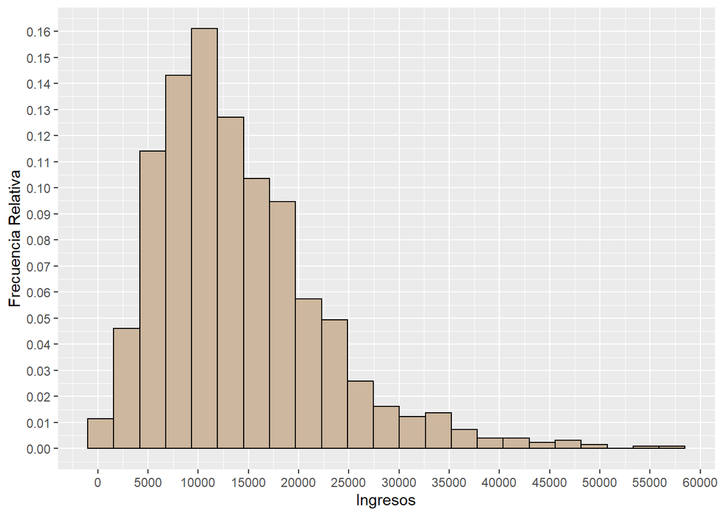

```r
ggplot(data = Datos, aes(x=ingresos ))+
geom_histogram(aes(y = after_stat(count / sum(count))) , breaks=L , fill="bisque3", color="black")+
 scale_y_continuous( n.breaks = 15 )+
  scale_x_continuous(n.breaks = 12)+
  labs(x = "Ingresos",y = "Frecuencia Relativa")
```

Añadimos al histograma anterior lineas discontinuas verticales asociadas a los valores de algunos estadisticos descriptivos:

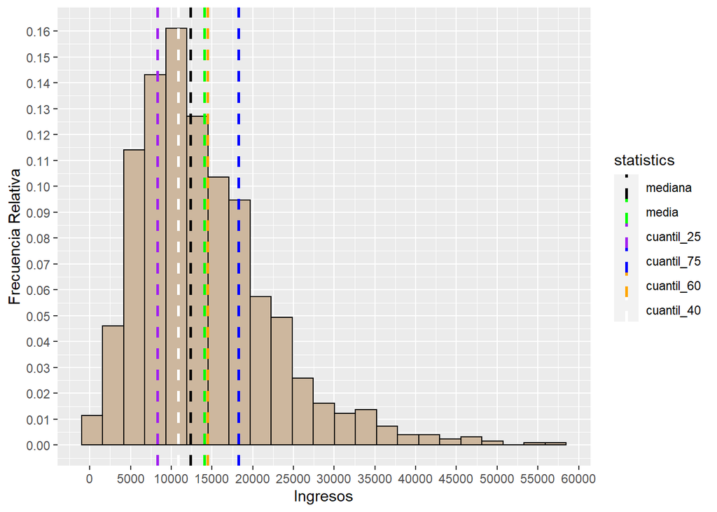

# Gráfico de Barras

Un *gráfico de barras* es un gráfico de barras no apliladas empleado para representar las frecuencias absolutas o relativas de una variable categorica.

El gráfico de barras se construye de la siguiente manera:

En el *eje x* contiene el recorrido de la variable categorica. En el *eje y* las frecuencias absolutas o relativas de los intervalos de categorización en la variable cuantitativa.

En el *interior* del gráfico hay barras no apiladas, tantas como categorias tiene la variable categorica, cada barra está asignada a una categoria de la variable, y tiene una altura igual a la frecuencia absoluta o relativa de la categoria en la variable categorica.

Generamos un gráfico de barras de la variable categórica *neduc* (nivel de educación):

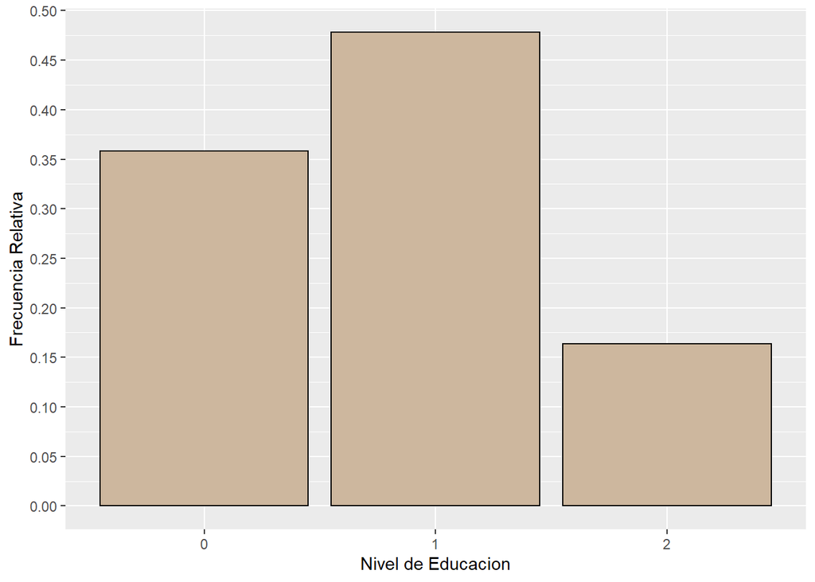

```r
ggplot(data = Datos, aes(x=neduc ))+
geom_bar(aes(y = after_stat(count / sum(count))) ,
 fill="bisque3", color="black")+
 scale_y_continuous( n.breaks = 15 )+
  labs(x = "Nivel de Educacion",
  y = "Frecuencia Relativa")
```

# Box-Plot

Generamos un box-plot de la variable cuantitativa *ingresos*

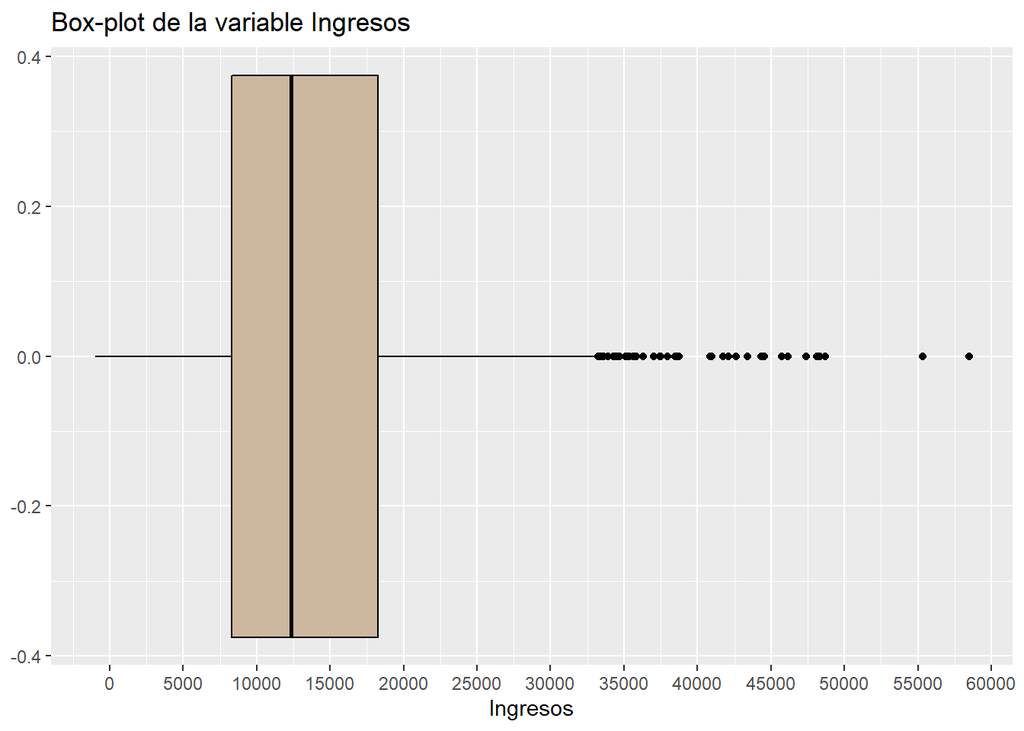

```r
ggplot(Datos) +
  geom_boxplot( aes(x = ingresos), fill="bisque3",
  color = 'black') +
  xlab("Ingresos") +
  ggtitle("Box-plot de la variable Ingresos ")+
  scale_x_continuous(n.breaks = 12)
```

El **box-plot** o gráfico de caja es un gráfico para variables cuantitativas que contiene los siguientes elementos:

- El **extremos izquierdo de la caja** (box) representa el valor $Q(0.25, X_k)$
- El **extremo derecho de la caja** representa el valor $Q(0.75, X_k)$
- La **linea del interior de la caja** representa el valor $Mediana(X_k)$
- El **extremo izquierdo de la linea horizontal** es:

$$\begin{equation*}
Max \left( Min(X_k) \hspace{0.1cm},\hspace{0.1cm} Q(0.25,X_k) - 1.5\cdot
RIC \right)
\end{equation*}$$

- El **extremo derecho de la linea horizontal** es:

$$\begin{equation*}
Min \left( Max(X_k) \hspace{0.1cm},\hspace{0.1cm} Q(0.75,X_k) + 1.5\cdot
RIC \right)
\end{equation*}$$

- Los puntos que estan mas alla del extremos izquierdo o derecho de la linea horizontal son consideradas **observaciones atípicas**.

Donde: $RIC= Q(0.75,X_k) - Q(0.25,X_k)$ es el **rango intercuartilico** de $X_k$.

Añadimos lineas verticales discontinuas con valores relevantes sobre el gráfico anterior:

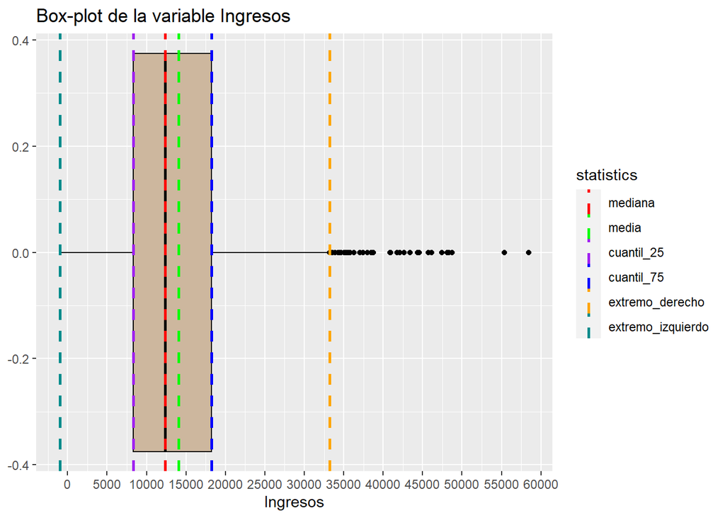

# Asimetria y Curtosis

## Coeficiente de Asimetria

El coeficiente de asimetria de Fisher de la variable cuantitativa $X_k$ es:

$$\begin{gather*}
Asimetria(X_k) = \dfrac{\overline{x_{k}}_{3}}{S(X_k)^{3}}
\end{gather*}$$

donde:
$$\begin{gather*}
\overline{x_{k}}_{3}=\dfrac{1}{n}\sum_{i=1}^{n} (x_{ik})^{3}
\end{gather*}$$

### Propiedades del coeficiente de asimetria

El **coeficiente de asimetria de Fisher** mide el **grado de simetria** de la distribucion de las observaciones de una variable respecto de su media aritmética.

- Si $Asimetria(X_k) > 0$ $\Rightarrow$ la distribución de $X_k$ es **asimétrica a la derecha**.
- Si $Asimetria(X_k) <0$ $\Rightarrow$ la distribución de $X_k$ es **asimétrica a la izquierda**.
- Si la distribución es **simétrica** respecto de la media $\Rightarrow$ $Asimetria(X_k)=0$ . Pero el recíproco no es cierto.

### Asimetria en R

```r
library(moments)

skewness(Datos$ingresos)
```

```
## [1] 1.304721
```

#### Comparación Asimetia

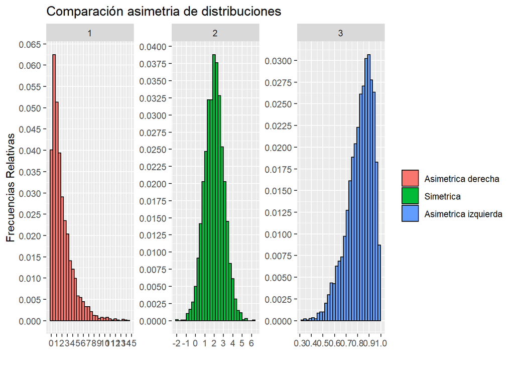

## Coeficiente de Curtosis

El **coeficiente de curtosis** de la variable cuantitativa $X_k$ es:

$$\begin{gather*}
Curtosis(X_k) = \dfrac{\overline{x_k}_{4}}{S(X_k)^{4}}
\end{gather*}$$

Donde:
$$\begin{gather*}
\overline{x_k}_{4}=\frac{1}{n}\sum_{i=1}^{n} (X_i)^{4}
\end{gather*}$$

### Propiedades del coeficiente de Courtosis

El **coeficiente de curtosis** mide principalemte el **grado de apuntamiento** de la distribucion de las observaciones de una variable.

- Si $Curtosis(X_k) > 3$ $\Rightarrow$ la distribucion de $X_k$ es **mas apuntada** y con colas mas gruesas **que la distribución normal**.
- Si $Curtosis(X_k) < 3$ $\Rightarrow$ la distribucion de $X_k$ es **menos apuntada** y con colas menos gruesas **que la distribución normal**.

### Curtosis en R

```r
library(moments)

kurtosis(Datos$ingresos)
```

```
## [1] 5.630726
```

#### Comparación Apuntamiento:

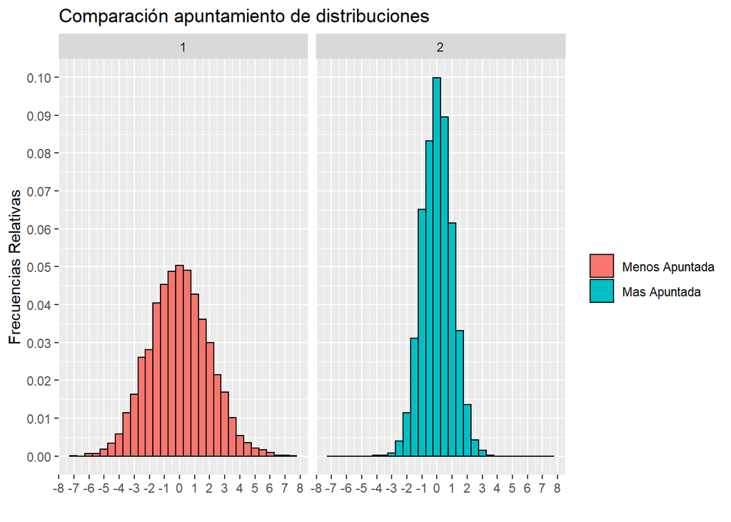

# Tablas de Frecuencias Relativas Conjuntas

## Tablas de Frecuencias Relativas Conjuntas para 2 variables

Vamos a crear una función en R a la que le metemos un par de variables y nos devuelve una tabla con las frecuencias relativas conjuntas de las dos variables.

Las caracteristicas de la función son las siguientes:

- **Entrada:** matriz de datos $X$
- **Entrada:** variables $V1$ y $V2$ de $X$
- $V1$ y $V2$ deben estar cargadas en R como vectores
- $V1$ y $V2$ pueden ser variables categoricas o cuantitativas categorizadas
- El recorrido de $V1$ tiene que ser $0:p1$ , con $p1=1,2,3,...$
- El recorrido de $V2$ tiene que ser $0:p2$ , con $p2=1,2,3,...$
- **Entrada:** $p1$ , $p2$
- $V1$ es la variable de la parte superior (columnas) de la tabla
- $V2$ es la variable de la parte inferior (filas) de la tabla

```r
Tabla_Frecuencias_Relativas_Conjuntas_2_Variables <- function(X, V1, V2, p1, p2){

tabla<- matrix(NA, nrow=p2+1, ncol=p1+1 )

for(i in 0:p2){
  for(j in 0:p1){

tabla[i+1,j+1] <- ( dim( ( X %>% select(V1,V2) %>% filter(V1==j & V2==i) ) )[1] / dim(X)[1] )
  }
}

rownames(tabla)<-0:p2
colnames(tabla)<-0:p1

print("V1 esta en la parte superior (columnas) de la tabla y V2 en la parte inferior (filas)")

tabla <- as.data.frame(tabla)

return(tabla)
}
```

**Ejemplo 1:** Dos variables categoricas

```r
Datos$edad <- recode(Datos$edad, "1"="0", "2"="1", "3"="2", "4"="3")
Datos$edad<- as.double( Datos$edad )
edad<-Datos$edad

Datos$genero <- recode(Datos$genero, "1"="0", "2"="1" )
Datos$genero <- as.double( Datos$genero )
genero <- Datos$genero

Tabla_Frecuencias_Relativas_Conjuntas_2_Variables(X=Datos, V1=edad , V2=genero, p1=3, p2=1 )
```

```
## [1] "V1 esta en la parte superior (columnas) de la tabla y V2 en la parte inferior (filas)"
```

|  | 0 | 1 | 2 | 3 |
| --- | --- | --- | --- | --- |
| 0 | 0.0631068 | 0.2160194 | 0.1108414 | 0.1076052 |
| 1 | 0.0590615 | 0.2119741 | 0.1116505 | 0.1197411 |

**Ejemplo 2:** Una variable categorica y otra cuantitativa

Lo primero es categorizar la variable cuantitativa, para ello aplicamos una regla facil de categorizacion como la de la media

```r
L<- c(min(Datos$ingresos), mean(Datos$ingresos), max(Datos$ingresos))

b<-cut(Datos$ingresos , breaks = L , include.lowest = T)

ingresos_categorizados_regla_media <- recode(b, "[-1e+03,1.41e+04]"=0 , "(1.41e+04,5.85e+04]"=1)
```

Hay que añadir la variable *ingresos* categorizada a la matriz de datos

```r
Datos <- cbind(Datos, ingresos_categorizados_regla_media)
```

```r
Tabla_Frecuencias_Relativas_Conjuntas_2_Variables(X=Datos, V1=ingresos_categorizados_regla_media , V2=genero, p1=1, p2=1 )
```

```
## [1] "V1 esta en la parte superior (columnas) de la tabla y V2 en la parte inferior (filas)"
```

|  | 0 | 1 |
| --- | --- | --- |
| 0 | 0.2847896 | 0.2127832 |
| 1 | 0.2985437 | 0.2038835 |

Por ejemplo, la proporción de individuos que son hombres (genero=0) con ingresos superiores a la media (ingresos_categorizados_regla_media=1) es 0.21

Comprobación:

```r
# Calculamos manualmente la entrada (V1=0, V2=0)

 ( dim( ( Datos %>% select(ingresos_categorizados_regla_media, genero) %>% filter(ingresos_categorizados_regla_media==0 & genero==0) ) )[1] / dim(Datos)[1] )
```

```
## [1] 0.2847896
```

Para dos variables cuantitativas seria un procedimiento analogo.

## Tablas de Frecuencias Relativas Conjuntas para 3 variables:

Vamos a crear una función en R a la que le metemos tres variables y nos devuelve una tabla con las frecuencias relativas conjuntas de las tres variables, pero considerando un valor fijo de una de ellas.

Las caracteristicas de la función son las siguientes:

- **Entrada:** matriz de datos $X$
- **Entrada:** variables $V1$ , $V2$ y $V3$ de $X$
- $V1$ , $V2$ y $V3$ deben estar cargadas en R como vectores
- $V1$ , $V2$ y $V3$ pueden ser variables categoricas o cuantitativas categorizadas
- El recorrido de $V1$ tiene que ser $0:p1$ , con $p1=1,2,3,...$
- El recorrido de $V2$ tiene que ser $0:p2$ , con $p2=1,2,3,...$
- El recorrido de $V3$ tiene que ser $0:p2$ , con $p3=1,2,3,...$
- **Entrada:** $p1$ , $p2$, $p3$
- $V1$ es la variable de la parte superior (columnas) de la tabla
- $V2$ es la variable de la parte inferior (filas) de la tabla
- $V3$ es la variable cuyo valor se fija
- **Entrada** el valor fijado de $V3$ (*valor_fijado_V3*)

```r
Tabla_Frecuencias_Relativas_Conjuntas_3_Variables <- function(X, V1, V2, p1, p2, V3, valor_fijado_V3){

tabla<- matrix(NA, nrow=p2+1, ncol=p1+1 )


for(i in 0:p2){
  for(j in 0:p1){

    tabla[i+1,j+1] <- ( dim( ( X  %>% filter( V1==j & V2==i & V3==valor_fijado_V3 ) ) )[1] / dim(X)[1] )

  }
}
 rownames(tabla)<-0:p2
 colnames(tabla)<-0:p1

 print("Tabla de contingencia conjunta entre las variables V1 , V2 y V3, donde V1 esta en la parte superior (columnas) de la tabla y V2 en la inferior (filas), y V3 toma siempre un mismo valor fijado")

 tabla <- as.data.frame(tabla)

 return(tabla)
}
```

**Ejemplo:** una variable cuantitativa y dos variables categoricas

```r
Tabla_Frecuencias_Relativas_Conjuntas_3_Variables(X=Datos, V1= ingresos_categorizados_regla_media , V2= genero , p1=1, p2=1, V3= edad, valor_fijado_V3=3)
```

```
## [1] "Tabla de contingencia conjunta entre las variables V1 , V2 y V3, donde V1 esta en la parte superior (columnas) de la tabla y V2 en la inferior (filas), y V3 toma siempre un mismo valor fijado"
```

|  | 0 | 1 |
| --- | --- | --- |
| 0 | 0.0776699 | 0.0299353 |
| 1 | 0.0938511 | 0.0258900 |

Comprobación:

```r
# Calculamos manualmente la entrada (V1=0, V2=0, V3=3)

( dim( ( Datos  %>% filter( ingresos_categorizados_regla_media==0 & genero==0 & edad==3 ) ) )[1] / dim(Datos)[1] )
```

```
## [1] 0.0776699
```

Se puede extender esta idea a mas dimensiones (4,5,6… variables), aunque no es habitual un analisis con mas de 3 varibles.

# Tabla de Frecuencias Relativas Condicionadas

## Tabla de Frecuencias Relativas Condicionadas con 2 variables

La idea es obtener una tabla de frecuencias relativas para 2 variables, $V1$ y $V2$, donde $V1$ condiciona a $V2$ , $(V2 | V1)$.

Las caracteristicas de la función son las siguientes:

- **Entrada:** matriz de datos $X$
- **Entrada:** variable $V1$
- **Entredas** $V2\_indice$ es el indice de la variable V2 , si la variable $V2$ ocupa la columna 6 en $X$, entonces V2_indice=6
- $V1$ debe estar cargada en R como vector
- $V1$ y $V2$ pueden ser variables categoricas o cuantitativas categorizadas
- El recorrido de $V1$ tiene que ser $0:p1$ , con $p1=1,2,3,...$
- El recorrido de $V2$ tiene que ser $0:p2$ , con $p2=1,2,3,...$
- **Entrada:** $p1$ y $p2$
- $V1$ es la variable que **condiciona**, la de la parte superior (columnas) de la tabla
- $V2$ es la variable de la parte inferior (filas) de la tabla

```r
Tabla_Frecuencias_Relativas_Condicionadas_2_Variables <- function(X, V1, V2_indice, p1, p2 ){

tabla<- matrix(NA, nrow=p2+1, ncol=p1+1 )

for(i in 0:p2){
  for(j in 0:p1){

    X_new <- X %>% filter( V1==j)

    V2_new<- X_new[, V2_indice]

    tabla[i+1,j+1] <- (dim( ( X_new  %>% filter(V2_new==i) ) )[1] / dim(X_new)[1])
  }
}

 rownames(tabla)<-0:p2
 colnames(tabla)<-0:p1

print(" V1  es la variable que condiciona y esta en la parte superior (columnas) de la tabla y  V2 en la inferior (filas)")

 tabla <- as.data.frame(tabla)

 return(tabla)
}
```

```r
Tabla_Frecuencias_Relativas_Condicionadas_2_Variables(Datos, V1=genero, V2_indice=9, p1=1, p2=1)
```

```
## [1] " V1  es la variable que condiciona y esta en la parte superior (columnas) de la tabla y  V2 en la inferior (filas)"
```

|  | 0 | 1 |
| --- | --- | --- |
| 0 | 0.5723577 | 0.5942029 |
| 1 | 0.4276423 | 0.4057971 |

```r
# La variable V2 es la de indice 9 de la matriz de datos, que es la variable ingresos categorizada con la regla de la media.
```

Por ejemplo, la proporción de personas con ingresos superiores a la media (ingresos_categorizados_regla_media=1), dentro del grupo de los hombres (genero=0) es 0.43

Comprobación:

```r
# Comprobamos cual es la variable V2 usada en el codigo anterior

names(Datos %>% select(9))
```

```
## [1] "ingresos_categorizados_regla_media"
```

```r
# Calculamos manualmente la entrada (V1=0, V2=0)

dim((Datos %>% filter(genero==0))%>% filter(ingresos_categorizados_regla_media==0))[1] / dim((Datos %>% filter(genero==0)))[1]
```

```
## [1] 0.5723577
```

## Tablas de Frecuencias Relativas Condicionadas con 3 variables

La idea es obtener una tabla de frecuencias relativas para 3 variables, $V1$ , $V2$ y $V3$, donde $V1$ y $V3$ condicionan a $V2$ , $(V2 | V1 , V3 )$, y $V3$ tiene un valor fijado.

Las caracteristicas de la función son las siguientes:

- **Entrada:** matriz de datos $X$
- **Entrada:** variable $V1$ y $V3$
- **Entredas** $V2\_indice$ es el indice de la variable V2 , si la variable $V2$ ocupa la columna 6 en $X$, entonces V2_indice=6
- $V1$ y $V3$ debe estar cargada en R como vector
- $V1$, $V2$ y $V3$ pueden ser variables categoricas o cuantitativas categorizadas
- El recorrido de $V1$ tiene que ser $0:p1$ , con $p1=1,2,3,...$
- El recorrido de $V2$ tiene que ser $0:p2$ , con $p2=1,2,3,...$
- El recorrido de $V3$ tiene que ser $0:p3$ , con $p3=1,2,3,...$
- **Entrada:** $p1$ , $p2$
- $V1$ es una de las dos variables que **condicionan**, la de la parte superior (columnas) de la tabla
- $V3$ es la otra variable que condiciona, pero tiene un valor fijado
- $V2$ es la variable de la parte inferior (filas) de la tabla

```r
Tabla_Frecuencias_Relativas_Condicionadas_3_Variables <- function(X, V1, V2_indice, p1, p2 , V3, valor_fijado_V3 ){

tabla<- matrix(NA, nrow=p2+1, ncol=p1+1 )


for(i in 0:p2){
  for(j in 0:p1){

     X_new <- X %>% filter( V1==j & V3==valor_fijado_V3)

     V2_new<- X_new[, V2_indice]

     tabla[i+1,j+1] <- ( dim( ( X_new  %>% filter(V2_new==i) ) )[1] / dim(X_new)[1] )

  }
}
 rownames(tabla)<-0:p2
 colnames(tabla)<-0:p1

 print("V1 y V3 condicionan a V2, V3 toma valor fijo, V1 está en la parte superior (columnas) de la tabla y V2 en la inferior (filas)")

 tabla <- as.data.frame(tabla)

 return(tabla)
}
```

```r
Tabla_Frecuencias_Relativas_Condicionadas_3_Variables(Datos ,V1=genero, V2_indice=9, p1=1, p2=1, V3=edad, valor_fijado_V3 =3 )
```

```
## [1] "V1 y V3 condicionan a V2, V3 toma valor fijo, V1 está en la parte superior (columnas) de la tabla y V2 en la inferior (filas)"
```

|  | 0 | 1 |
| --- | --- | --- |
| 0 | 0.7218045 | 0.7837838 |
| 1 | 0.2781955 | 0.2162162 |

Comprobación:

```r
# Comprobamos cual es la variable V2 usada en el codigo anterior

names(Datos %>% select(9))
```

```
## [1] "ingresos_categorizados_regla_media"
```

```r
# Calculamos manualmente la entrada (V1=0, V2=0, V3=3)

dim((Datos %>% filter(genero==0 & edad==3) )%>% filter(ingresos_categorizados_regla_media==0))[1] / dim((Datos %>% filter(genero==0 & edad==3) ))[1]
```

```
## [1] 0.7218045
```